# Summary Plots and Statistics for Glider Odontocete Events

Summary tables and plots to aid in manual assessment of potential false killer whale events in glider data

Selene Fregosi

17 May 2024

Summaries generated: 2024 May 17 22:15 UTC

### Setup

Load needed libraries.

```r
# load all libraries
devtools::install_github('taikisan21/PAMpal')
library(PAMpal)
# library(kableExtra) # known bug with R ver 4.3.0 so install from github
devtools::install_github('kupietz/kableExtra')
library(kableExtra)
library(ggplot2)
library(RSQLite)
library(tuneR)
# library(wesanderson)
library(here)

# I don't think we need these but saving here in case
# library(dplyr)
# library(tcltk)
# library(manipulate)
```

Set user-defined variables.

```r
# name project
ProjID <- 'MHI UxS Glider Project'

# combine trip, recorder, pg version (all defined in YAML) to single run string
pgRunStr <- paste0(params$pgver, '_glider_banter_', params$mission)

# define subfolder paths based on selected analysis folder and trip strings
path_to_db <- file.path(params$path_pg, 'databases')
path_to_binaries <- file.path(params$path_pg, 'binaries', pgRunStr)

# assemble some file names
# pamguard database
dbFile <- file.path(path_to_db, paste0(pgRunStr, '.sqlite3'))
# already processed acoustic study 'dets' file
detsFile <- file.path(params$path_dets, 'dets',
                      paste0(params$pgver, '_', params$mission, '_dets.rda'))
detsFiltFile <- file.path(params$path_dets, 'dets_filtered',
                          paste0(params$pgver, '_', params$mission, '_detsFilt.rda'))
# specify calibration file
# calFile <- params$calFile # pull from YAML

# set path to reference spectra if will be used
path_to_refSpec <- file.path(params$path_to_refSpec) # pull from YAML
# specify which reference spectra to plot
# refSpecList = c('Gm', 'Pc')
refSpecList <- params$refSpecList # pull from YAML
refSpecSp <- params$refSpecSp


# ALTERNATIVE SELECT PATHS
# path_pg <- choose.dir(default = "", caption = "Select path to pamguard folder that contains databases and binaries folders")
# # select path to database files
# path_to_db <- choose.dir(default = "", caption = "Select path to folder with all database files")
# # select path to specific binary drift file
# path_to_binaries <- choose.dir(default="", caption = "Select path to specific drift main folder")

# set up datebase driver
sqlite <- dbDriver("SQLite")

#Set time zone to UTC
Sys.setenv(TZ = 'UTC')

# reference spectra colors - allows for up to 6 ref specs
# pastel
# rsPalette <- c('#66c2a5', '#fc8d62', '#8da0cb', '#e78ac3',
#                '#a6d854', '#ffd92f')
# bold
rsPalette <- c('#1b9e77', '#d95f02', '#7570b3', '#e7298a',
               '#66a61e', '#e6ab02')
```

#### Load and prep AcousticStudies

If already created, load an existing `dets` PAMpal AcousticStudy object for event processing. We need to load both the unfiltered `dets` and filtered `detsFilt` AcousticStudies.

```r
# load existing dets AcousticStudy (created with
# workflow_generate_acousticStudies.R)
# load(detFile)
if (file.exists(detsFile)){
  load(detsFile)
  cat('Loaded', detsFile, '\n')
} else {
  cat('No AcousticStudy \'dets\' file available', '\n')
}
```

```
## Loaded T:/glider_MHI_analysis/classification/dets/pam20207b_sg639_MHI_Apr2023_dets.rda
```

```r
if (file.exists(detsFiltFile)){
  load(detsFiltFile)
  cat('Loaded', detsFiltFile, '\n')
} else {
  cat('No AcousticStudy \'detsFilt\' file available', '\n')
}
```

```
## Loaded T:/glider_MHI_analysis/classification/dets_filtered/pam20207b_sg639_MHI_Apr2023_detsFilt.rda
```

```r
# summarize how many events
nEvents <- length(names(events(dets)))
# number of events may change after filtering (all clicks may be filtered out)
nEventsFilt <- length(names(events(detsFilt)))
```

Loaded T:/glider_MHI_analysis/classification/dets/pam20207b_sg639_MHI_Apr2023_dets.rda and T:/glider_MHI_analysis/classification/dets_filtered/pam20207b_sg639_MHI_Apr2023_detsFilt.rda:

**134 events** before filtering and **134 events** after filtering.

#### Load reference spectra, if specified

Load the reference spectra for plotting, if set with `refSpecList`.

```r
# refSpecList is specified in YAML params. Can be one or multiple species
# for single species specify as char string without quotations e.g., refSpecPc
# for multiple species, specify with call to R and c()
#     e.g., !r c('meanSpecGm', 'refSpecPc_LLHARP')

if (!is.null(refSpecList)){
  refSpecs = list()
  for (rs in refSpecList){
    refSpecs[[rs]] = read.csv(file.path(path_to_refSpec, paste0(rs, '.csv')))
  }
}
```

#### Define needed functions

Source some external functions

```r
source(file.path(params$path_llamp, 'R', 'functions', 'loadMultiBinaries.R'))
source(file.path(params$path_llamp, 'R', 'functions', 'plotContours.R'))
source(file.path(params$path_llamp, 'R', 'functions', 'clickSummary.R'))
source(file.path(params$path_llamp, 'R', 'functions', 'whistleSummary.R'))
```

### Event summaries

Click plots (other than the SNR plot) only show clicks with SNRs >= 15 dB.

```r
for (iEvent in c(1:10)){ #(iEvent in c(1:nEventsFilt)){
  # iEvent = 6 # for testing
  # ("pagebreak \n")

  # extract this event UID string
  eventList <- events(detsFilt)
  eventUID <- names(eventList)[iEvent]

  # set header for this event and print time
  cat('\n\n#### Event ID:   ', names(eventList)[iEvent], '\n')
  cat('Time:   ', format(eventList[[eventUID]]@ancillary$grouping$start,
                         '%Y-%m-%d %H:%M%Z'), ' to ',
      format(eventList[[eventUID]]@ancillary$grouping$end, '%Y-%m-%d %H:%M%Z'),
      '\n')

  ###### summarize clicks ######
  cl <- clickSummary(detsFilt, eventUID)

  cat('\nEvent contains', nrow(getClickData(dets[[eventUID]])),
      'original clicks,', paste0('**', cl$nClicks), 'valid clicks** after',
      'filtering.\n')
  cat('\n')

  ###### summarize whistles ######
  wl <- whistleSummary(detsFilt, eventUID)

  cat('\nEvent contains', paste0('**', wl$nWhistles), 'whistles**.\n')
  cat('\n')

  ###### click plots and table ######

  cat('\n##### Click plots and table\n')
  cat('\n SNR histogram includes all filtered clicks. Other plots contain only',
      'clicks with SNR >= 15 dB', paste0('(**n = ', cl$nGoodClicks, ' clicks**)'),
      '.\n')
  cat('\n')


  # if any clicks...
  if (cl$nClicks > 0){
    # histogram of all clicks and SNR >= 15 dB cut off
    xMax <- max(c(15, ceiling(max(cl$snr)) + 2)) # whichever is bigger
    hist(cl$snr, breaks = seq(from = floor(min(cl$snr)),
                              to = xMax, by = 2),
         main = 'Click SNR', sub = '(all filtered clicks)', xlab = 'SNR')
    abline(v = 15, lty = 2, lwd = 2, col = 'red4')

  }

  # if sufficient good clicks...
  if (cl$nGoodClicks > 0) {
    # histogram of click durations - good clicks only
    subStr <- paste0('(high SNR clicks, n=', cl$nGoodClicks, ')')
    hist(cl$goodClicks$duration,
         breaks = seq(from = 0, to = max(cl$goodClicks$duration) + 100,
                      by = 100), main = 'Click duration', sub = subStr,
         xlab = expression(paste('duration [', mu, 's]')))
    abline(v = median(cl$goodClicks$duration), lty = 2, lwd = 2, col = 'black')
    legend('topright', legend = 'median', lty = 2, lwd = 2, col = 'black')


    cat('\n')
    cat('\n')


    # Calculate and plot Concatenated and Mean Spectrum for clicks w/ max SNR > 15dB
    # NB: JLKM uses more exaggerated SNR (>40 dB) for BWs bc actual spectra may
    # be noisy for single clicks
    # reducing wl can give more accurate noise floor but 'smoother' spectrum
    # increasing wl will give more exact spectrum but may exclude too many
    # clicks based on SNR (noise measure will overlap with click output; noise
    # is just measured as same wl from start of binary snippet and binaries
    # binary snippets are v short)
    # Trial and error - 256 works ok for LLHARP data = 1.28 ms
    # NB: JLKM uses 500 for beaked whales with samp rate 288k
    avgSpec <- calculateAverageSpectra(detsFilt, evNum = eventUID, wl = 256,
                                       channel = 1, norm = TRUE, noise = TRUE,
                                       sort = TRUE, snr = 15,
                                       plot = c(TRUE, FALSE))
    # concatenated spectrogram will get plotted within calculation

    # avg spectrum plots separately (bc adding stuff)
    if (!is.null(avgSpec)) {
      # Peak freq as calculated by calculateAvgerageSpectra -for subtitle
      peakFreq <- round(avgSpec$freq[which.max(avgSpec$avgSpec)]/1000, 2)

      plot(1, type = 'n', xlim = c(0, 100), ylim = c(min(avgSpec$avgSpec), 0),
           xlab = 'Frequency (kHz)', ylab = 'Normalized Magnitude (dB)',
           main = 'Average Spectrum', sub = paste0('Peak: ', peakFreq, 'kHz'))
      # add grid lines for frequency at 10 kHz intervals
      for (iline in ((0:15)*10)) {lines(c(iline,iline), c(-60,10), col="gray")}
      # add template spectra
      if (length(refSpecs) > 0){
        rsCols <- rsPalette[1:length(refSpecs)]
        for (rs in 1:length(refSpecs)){
          rsTmp <- refSpecList[rs]
          rsNorm <- refSpecs[[rsTmp]]
          rsMax <- max(rsNorm$dB)
          rsNorm$dBNorm <- rsNorm$dB - rsMax
          lines(rsNorm$frq, rsNorm$dBNorm, col = rsCols[rs], lwd = 2)
        }
      }

      # plot noise
      lines(avgSpec$freq/1000, avgSpec$avgNoise, lty = 3, lwd = 2)
      # plot avg spectrum
      lines(avgSpec$freq/1000, avgSpec$avgSpec, lty = 2, lwd = 3)
      # also plot median spectrum
      medSpec <- 20*log10(apply(avgSpec$allSpec, 1, function(y) {
        median(10^(y/20), na.rm = TRUE)}))
      medSpecNorm <- medSpec - max(medSpec, na.rm = TRUE)
      lines(avgSpec$freq/1000, medSpecNorm, lty = 1, lwd = 3)

      # add legend
      legend(x = 'topright', c(refSpecSp, 'Avg.', 'Med.', 'Noise'),
             lty = c(1, 1, 2, 1, 3), lwd = c(1, 1, 2, 3, 2),
             col = c(rsCols, 'black', 'black', 'black'), cex = 0.8)
    }


    # NB: JLKM BW approach has additional plots here:
    # IPI
    # Waveform of strongest click
    # Wigner plot
    # We are not including those here because not really useful for FKW, but if
    # interested in adding back in, see:
    #       https://github.com/jlkeating/PAMGuard_Event_Code


    cat('\n')
    cat('\n')


    # create median stats table for clicks with -15 dB TK noise cut off
    cat('\n\n Median statistics for', cl$nGoodClicks, 'high SNR clicks with',
        'SNR >= 15 dB.')
    cat('\n')

    cat(knitr::kable(cl$mt, format = 'html', caption = '', align = 'l',
                     row.names = FALSE) %>%
          kable_styling(bootstrap_options = c('basic', 'condensed'),
                        full_width = F))

  }  else { # no good clicks so no summary plots/table
    cat('\nNo clicks of sufficient SNR to plot or summarize.\n')
  }


  ###### whistle plots and table ######

  cat('\n##### Whistle plots and table\n')

  # if whistles present ...
  if (wl$nWhistles > 0) {
    # create median stats table for all whistles
    # cat('\n\n Median statistics for', wl$nWhistles, 'whistles.')
    # cat('\n')

    # plot whistle contours
    # map the needed binary files
    binFiles <- dets@events[[eventUID]]@files$binaries
    wmFileIdx <- grep(pattern = '^.*WhistlesMoans_Whistle_and_Moan.*\\.pgdf$',
                      binFiles)
    wmFiles <- dets@events[[eventUID]]@files$binaries[wmFileIdx]

    # load them
    whBin <- loadMultiBinaries(wmFiles)
    # trim to just the event time
    whBinEv <- whBin[names(whBin) %in%
                       detsFilt[[eventUID]]$Whistle_and_Moan_Detector$UID]

    # #plot - ggplot version/functionized
    # pc <- plotContours(whBinEv)
    # # print(pc)
    # pc + ggtitle(eventUID)
    #

    # get plot limits
    # xMax <- 0
    # yMax <- 0
    # for (wc in 1:length(names(whBinEv))){
    #   df <- data.frame(time = whBinEv[[wc]]$time - whBinEv[[wc]]$time[1],
    #                    freq = whBinEv[[wc]]$freq/1000)
    #   xMaxTmp <- max(df$time)
    #   yMaxTmp <- max(df$freq)
    #   if (xMaxTmp > xMax){xMax <- xMaxTmp}
    #   if (yMaxTmp > yMax){yMax <- yMaxTmp}
    # }
    # or use standard max lims
    xMax <- 1.5
    yMax <- 20

    # plot each line
    plot(1, type = 'n', xlim = c(0, round(xMax,2)), ylim = c(0, round(yMax,-1)),
         xlab = 'Time (s)', ylab = 'Frequency (kHz)',
         main = 'Whistle Contours')
    # add grid lines for frequency at 0.125 s and 5 kHz intervals
    for (iline in (seq(0,2,0.125))) {lines(c(iline,iline), c(-10,60),
                                           col="lightgray")}
    for (iline in (seq(0,50,5))) {lines(c(-0.5,2.5), c(iline,iline),
                                        col="lightgray")}
    # loop through each contour
    for (wc in 1:length(names(whBinEv))){
      df <- data.frame(time = whBinEv[[wc]]$time - whBinEv[[wc]]$time[1],
                       freq = whBinEv[[wc]]$freq/1000)
      lines(df$time, df$freq, col = rgb(0,0,0,0.4))
    }

    # plot histogram of median frequency
    hist(wl$wh$freqMedian/1000,
         breaks = seq(0, ceiling(max(wl$wh$freqMedian/1000)) + 1, 1),
         main = 'Histogram of whistle median frequency',
         xlab = 'Median frequency (kHz)')

    cat('\n')
    cat('\n')

    cat('Median statistics for n = ', wl$nWhistles, 'whistles.\n')
    # create median stats table for all whistles
    cat(knitr::kable(wl$mt, format = 'html', caption = '', align = 'l',
                     row.names = FALSE) %>%
          kable_styling(bootstrap_options = c('basic', 'condensed'),
                        full_width = F))

  } else {
    cat('\nNo whistles present.\n')
  }

  cat('\n')
  cat('\n\n --- \n\n')
  cat('\n')

}
```

#### Event ID: sg639_01

Time: 2023-04-12 05:17UTC to 2023-04-12 05:54UTC

Event contains 13334 original clicks, **1821 valid clicks** after filtering.

Event contains **4 whistles**.

##### Click plots and table

SNR histogram includes all filtered clicks. Other plots contain only clicks with SNR >= 15 dB (**n = 1756 clicks**) .

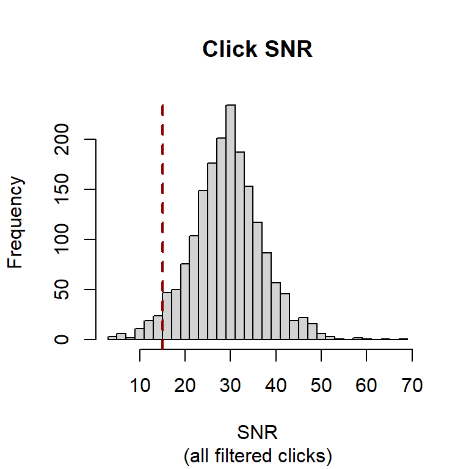

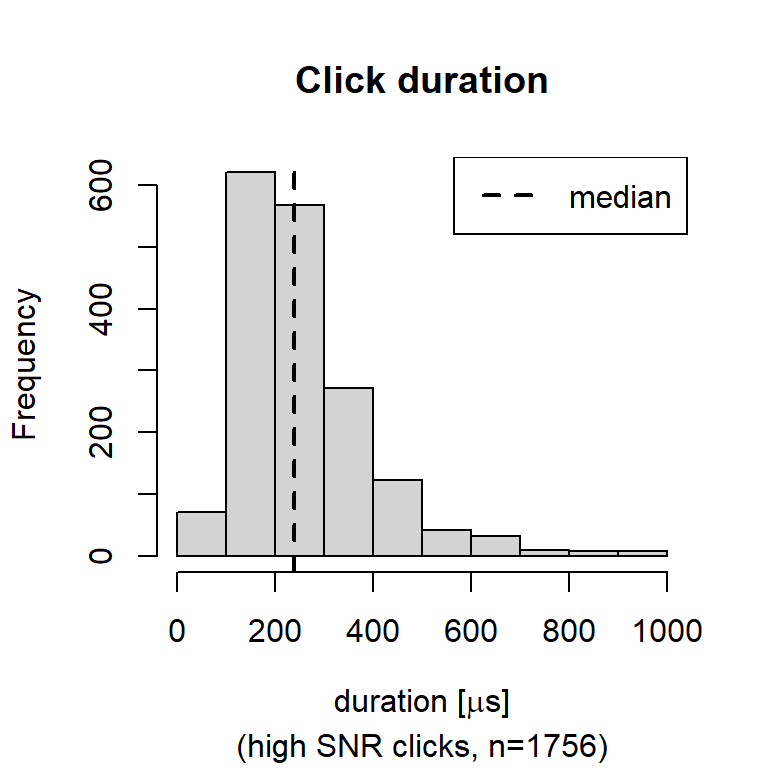

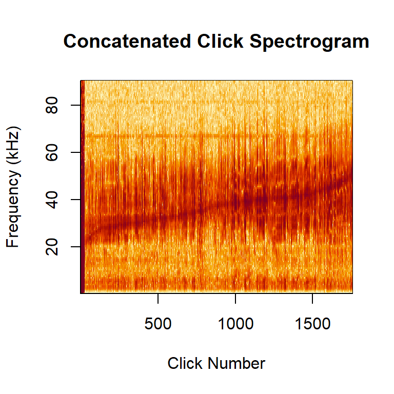

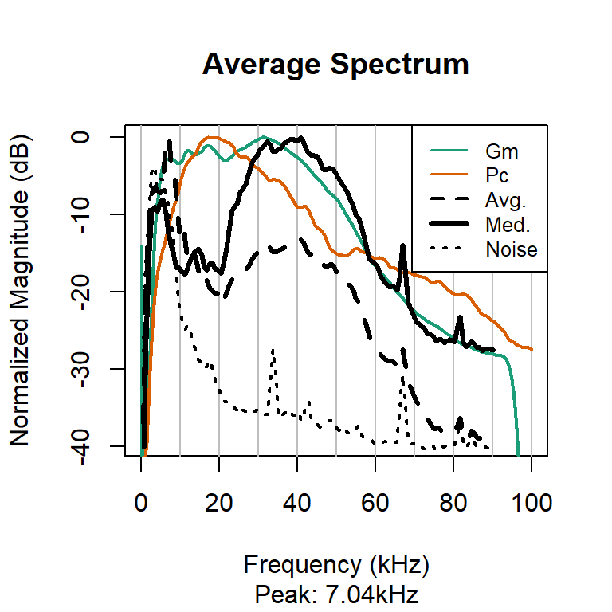

Median statistics for 1756 high SNR clicks with SNR >= 15 dB.

| parameter | value |
| --- | --- |
| Median Peak Frequency [kHz] | 36.7 |
| Median 3dB Center Frequency [kHz] | 34.5 |
| Median 10dB Center Frequency [kHz] | 36.3 |
| Median 3dB Bandwidth [kHz] (lower-upper) | 1.48 (33.8 - 35.5) |
| Median 10dB Bandwidth [kHz] (lower-upper) | 7.55 (31.8 - 40.9) |
| Median duration [μs] (25-75 percentile) | 239 (156 - 307) |

##### Whistle plots and table

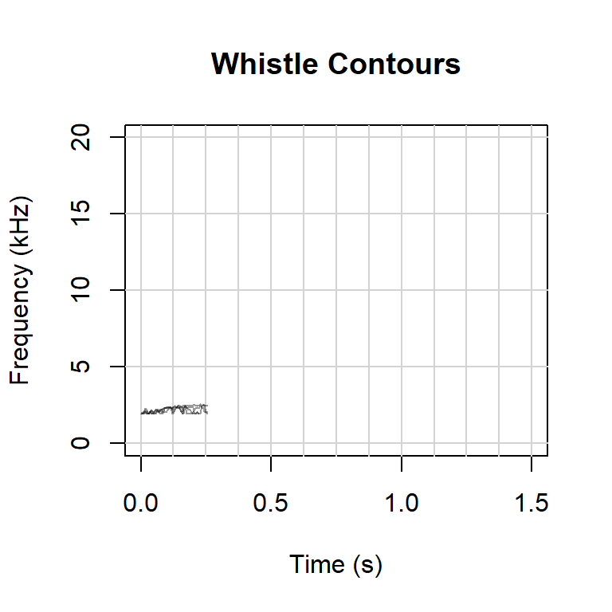

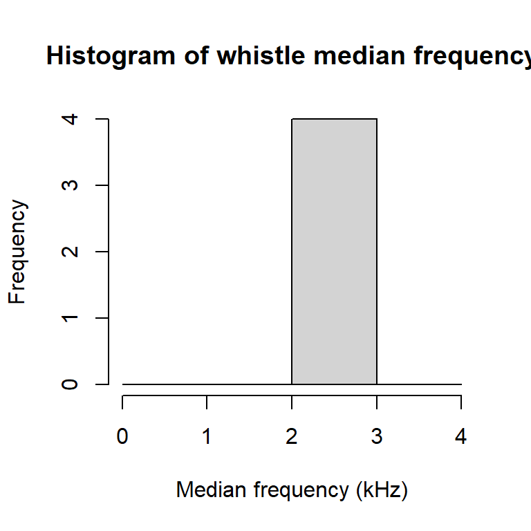

Median statistics for n = 4 whistles.

| parameter | value |
| --- | --- |
| Median begin frequency [kHz] | 1.94 |
| Median end frequency [kHz] | 2.02 |
| Median mean frequency [kHz] (SD) | 2.17 (0.18) |
| Median duration [s] | 0.261 |
| Median frequency range [kHz] (min-max) | 0.57 (1.94 - 2.51) |

#### Event ID: sg639_02

Time: 2023-04-12 06:34UTC to 2023-04-12 07:30UTC

Event contains 22966 original clicks, **3249 valid clicks** after filtering.

Event contains **5 whistles**.

##### Click plots and table

SNR histogram includes all filtered clicks. Other plots contain only clicks with SNR >= 15 dB (**n = 3121 clicks**) .

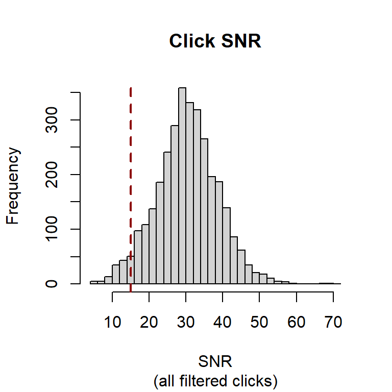

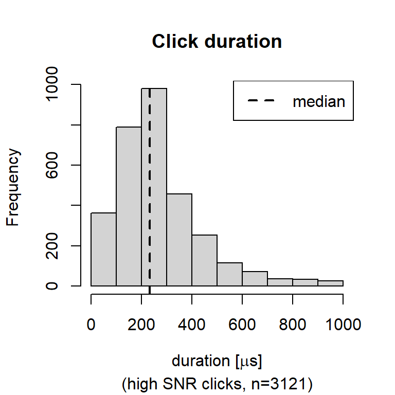

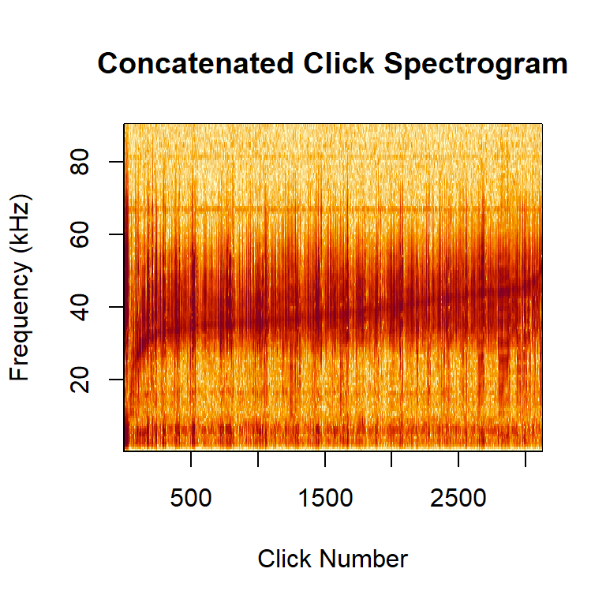

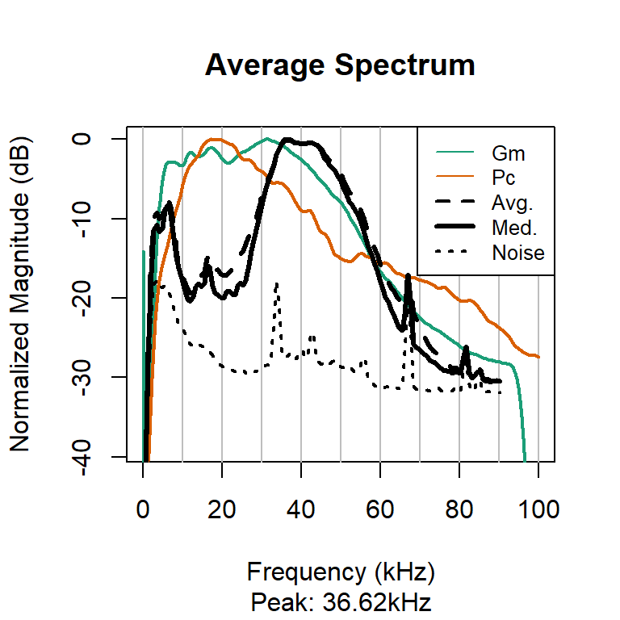

Median statistics for 3121 high SNR clicks with SNR >= 15 dB.

| parameter | value |
| --- | --- |
| Median Peak Frequency [kHz] | 37.9 |
| Median 3dB Center Frequency [kHz] | 37.2 |
| Median 10dB Center Frequency [kHz] | 39.2 |
| Median 3dB Bandwidth [kHz] (lower-upper) | 1.55 (36.1 - 38.4) |
| Median 10dB Bandwidth [kHz] (lower-upper) | 10.7 (32.7 - 45.3) |
| Median duration [μs] (25-75 percentile) | 234 (156 - 339) |

##### Whistle plots and table

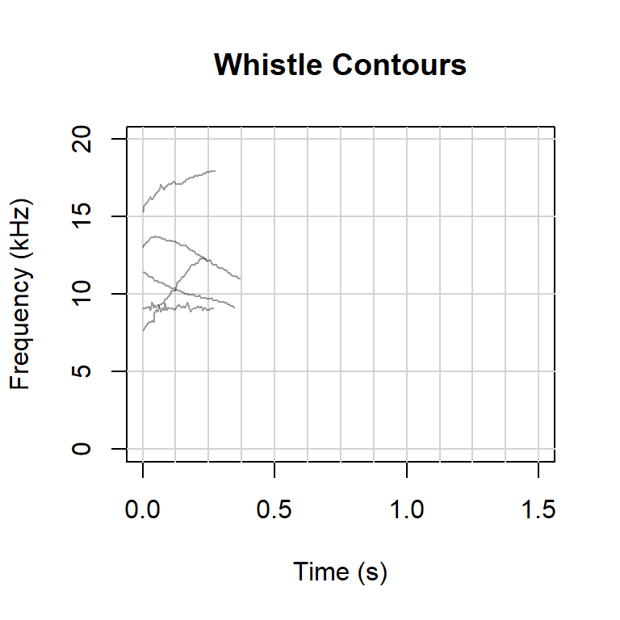

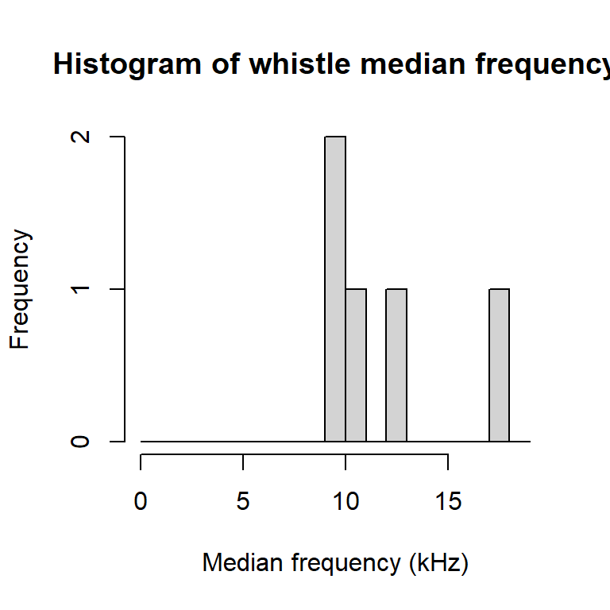

Median statistics for n = 5 whistles.

| parameter | value |
| --- | --- |
| Median begin frequency [kHz] | 11.44 |
| Median end frequency [kHz] | 11.00 |
| Median mean frequency [kHz] (SD) | 10.33 (0.67) |
| Median duration [s] | 0.278 |
| Median frequency range [kHz] (min-max) | 2.64 (9.15 - 12.32) |

#### Event ID: sg639_04

Time: 2023-04-12 08:21UTC to 2023-04-12 13:21UTC

Event contains 122787 original clicks, **4179 valid clicks** after filtering.

Event contains **26 whistles**.

##### Click plots and table

SNR histogram includes all filtered clicks. Other plots contain only clicks with SNR >= 15 dB (**n = 3823 clicks**) .

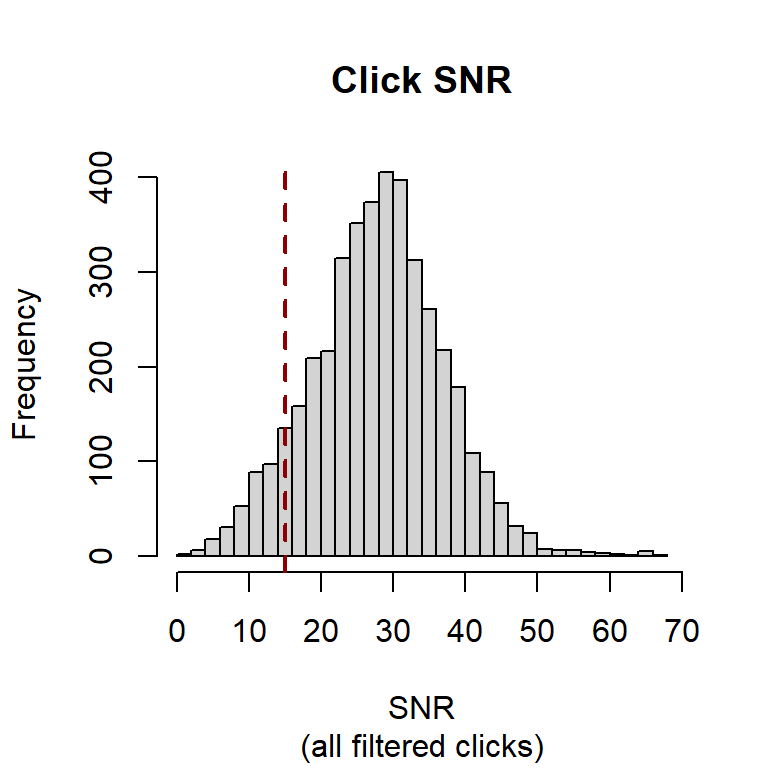

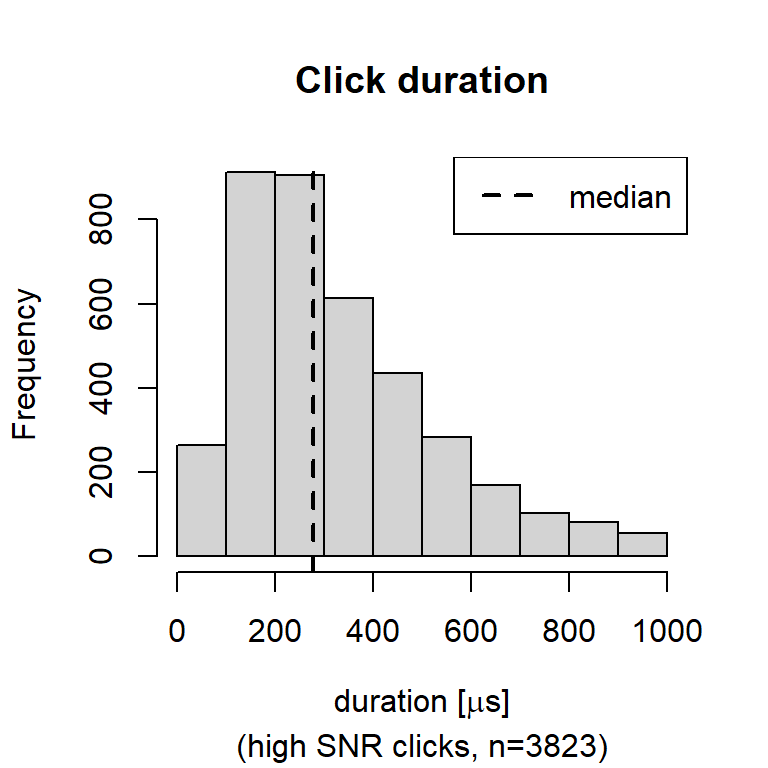

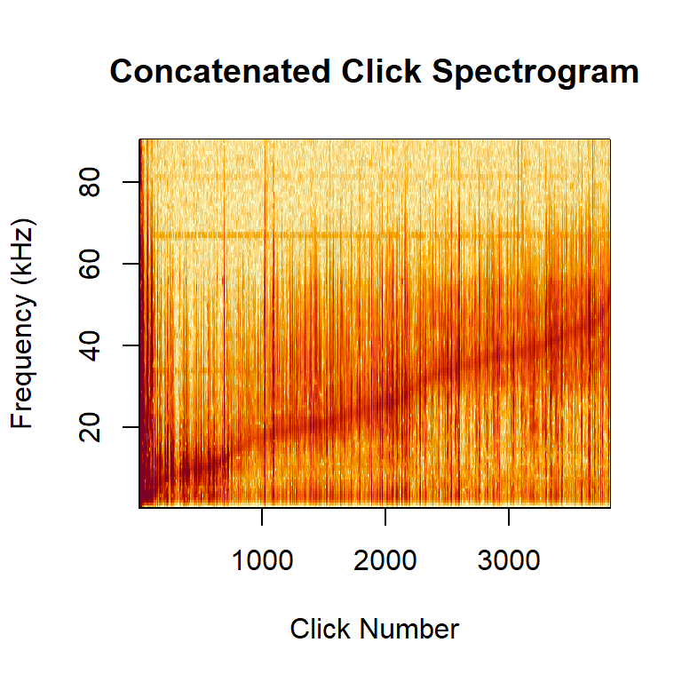

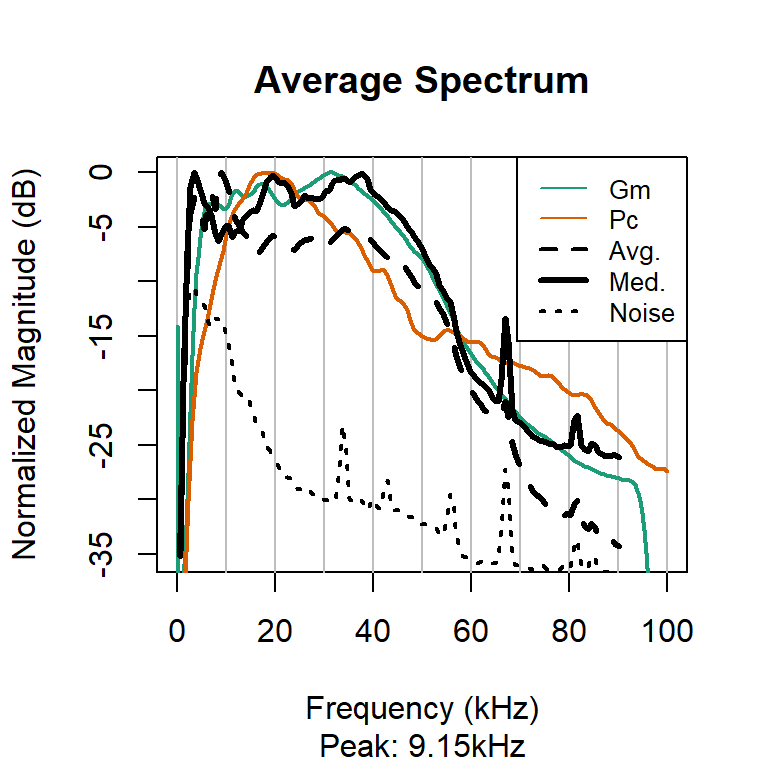

Median statistics for 3823 high SNR clicks with SNR >= 15 dB.

| parameter | value |
| --- | --- |
| Median Peak Frequency [kHz] | 25.1 |
| Median 3dB Center Frequency [kHz] | 25.5 |
| Median 10dB Center Frequency [kHz] | 25.7 |
| Median 3dB Bandwidth [kHz] (lower-upper) | 1.47 (24.6 - 26.5) |
| Median 10dB Bandwidth [kHz] (lower-upper) | 6.81 ( 22 - 29.6) |
| Median duration [μs] (25-75 percentile) | 278 (172 - 434) |

##### Whistle plots and table

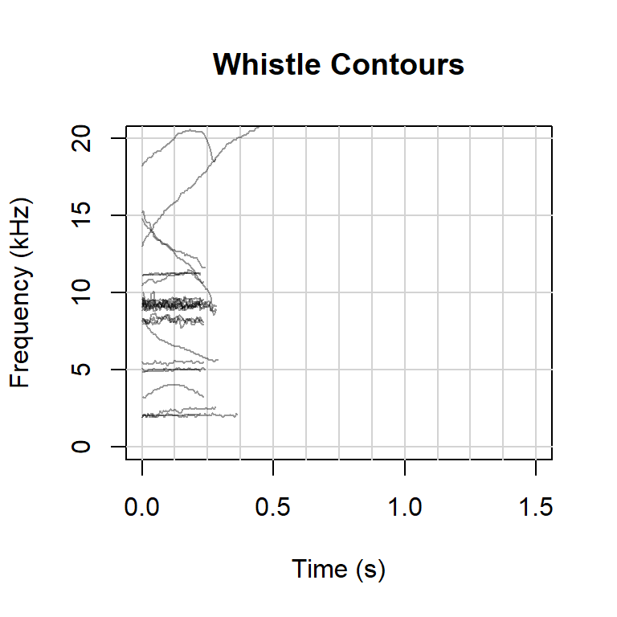

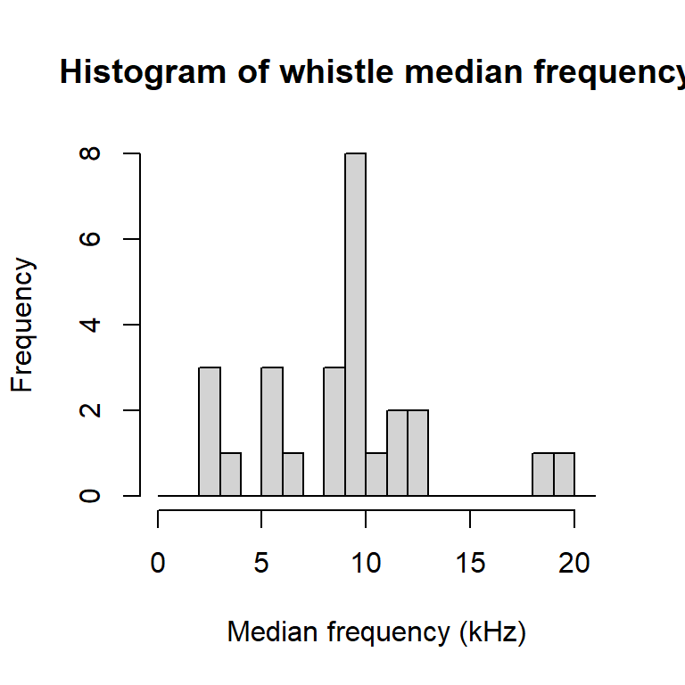

Median statistics for n = 26 whistles.

| parameter | value |
| --- | --- |
| Median begin frequency [kHz] | 9.11 |
| Median end frequency [kHz] | 9.02 |
| Median mean frequency [kHz] (SD) | 9.19 (0.20) |
| Median duration [s] | 0.239 |
| Median frequency range [kHz] (min-max) | 0.79 (8.80 - 9.64) |

#### Event ID: sg639_05

Time: 2023-04-12 13:46UTC to 2023-04-12 16:00UTC

Event contains 91841 original clicks, **13461 valid clicks** after filtering.

Event contains **59 whistles**.

##### Click plots and table

SNR histogram includes all filtered clicks. Other plots contain only clicks with SNR >= 15 dB (**n = 12886 clicks**) .

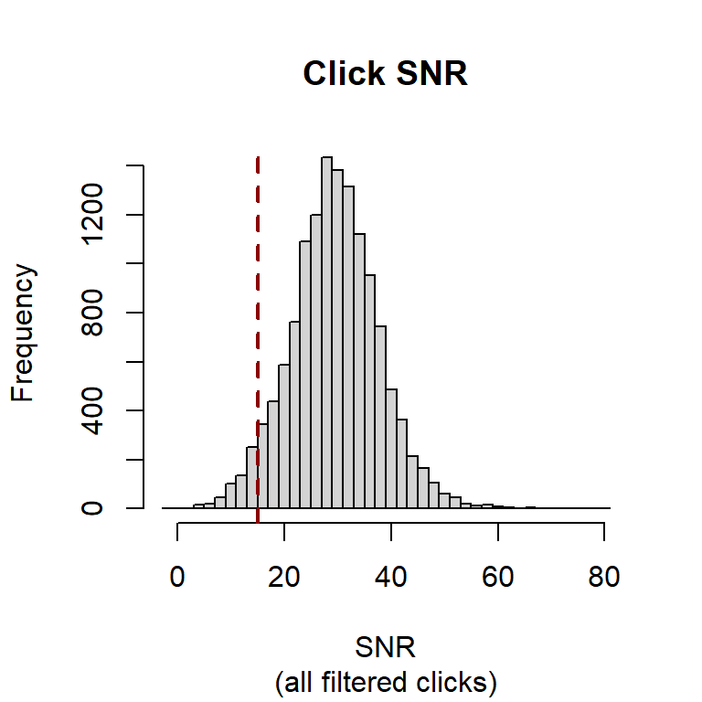

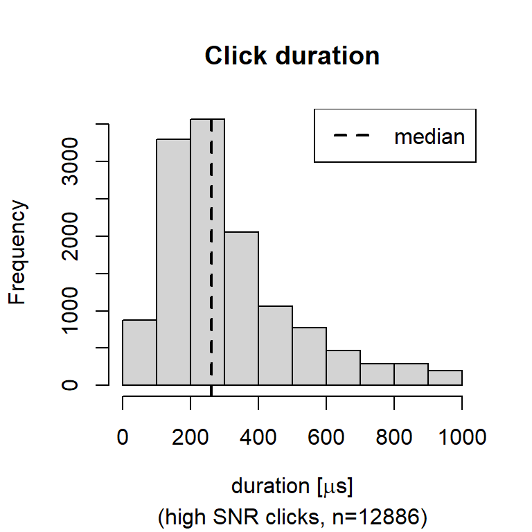

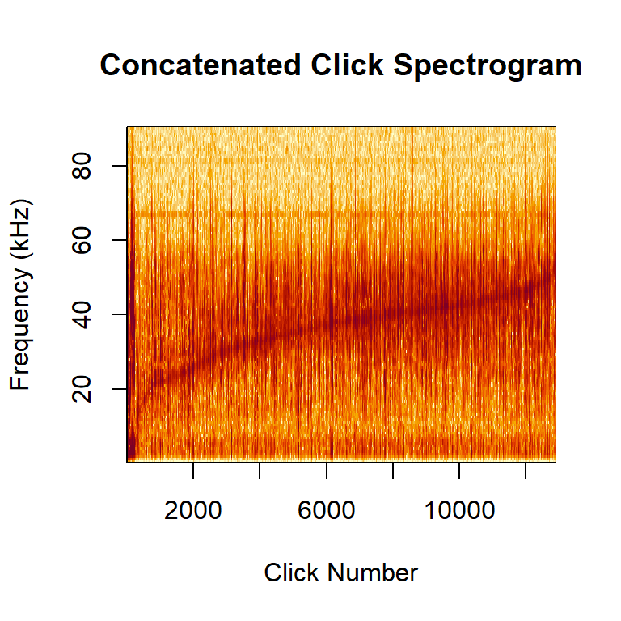

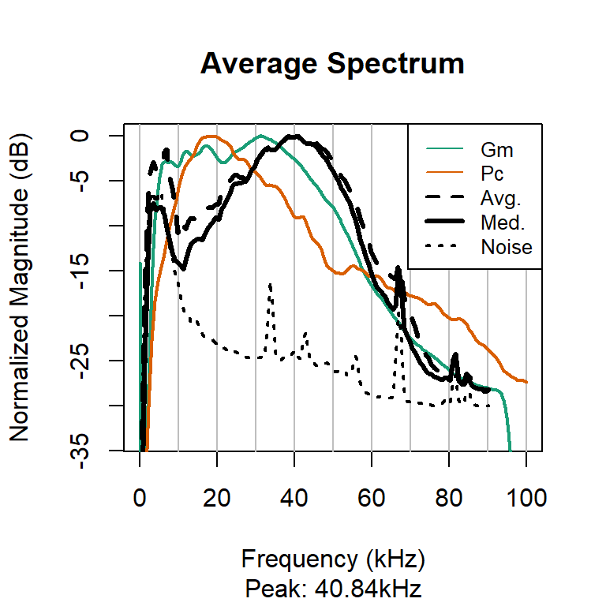

Median statistics for 12886 high SNR clicks with SNR >= 15 dB.

| parameter | value |
| --- | --- |
| Median Peak Frequency [kHz] | 37.9 |
| Median 3dB Center Frequency [kHz] | 37.3 |
| Median 10dB Center Frequency [kHz] | 37.8 |
| Median 3dB Bandwidth [kHz] (lower-upper) | 1.51 (36.2 - 38.2) |
| Median 10dB Bandwidth [kHz] (lower-upper) | 7.99 (32.6 - 42.3) |
| Median duration [μs] (25-75 percentile) | 261 (172 - 384) |

##### Whistle plots and table

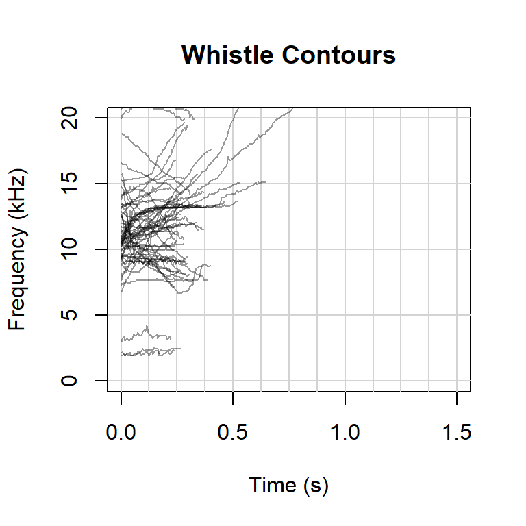

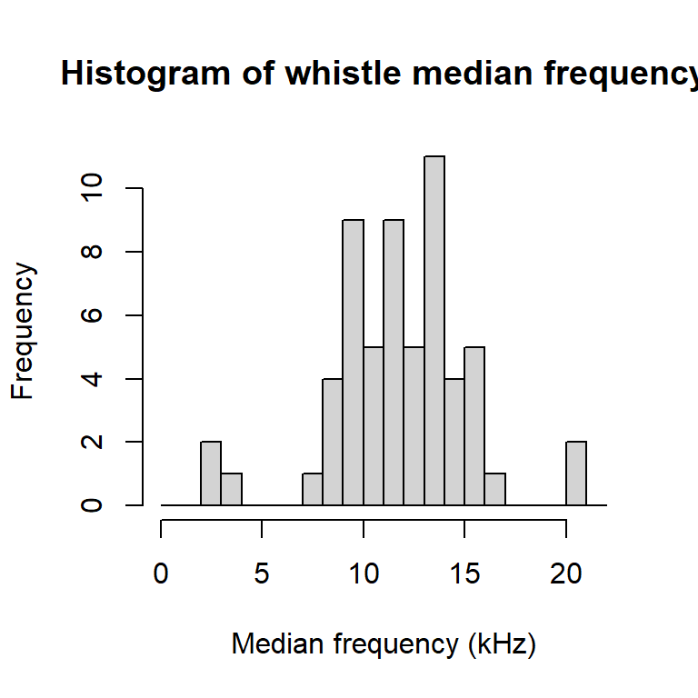

Median statistics for n = 59 whistles.

| parameter | value |
| --- | --- |
| Median begin frequency [kHz] | 10.65 |
| Median end frequency [kHz] | 12.06 |
| Median mean frequency [kHz] (SD) | 11.84 (0.72) |
| Median duration [s] | 0.29 |
| Median frequency range [kHz] (min-max) | 2.73 (10.30 - 13.38) |

#### Event ID: sg639_06

Time: 2023-04-12 21:38UTC to 2023-04-12 22:40UTC

Event contains 32940 original clicks, **2202 valid clicks** after filtering.

Event contains **755 whistles**.

##### Click plots and table

SNR histogram includes all filtered clicks. Other plots contain only clicks with SNR >= 15 dB (**n = 2031 clicks**) .

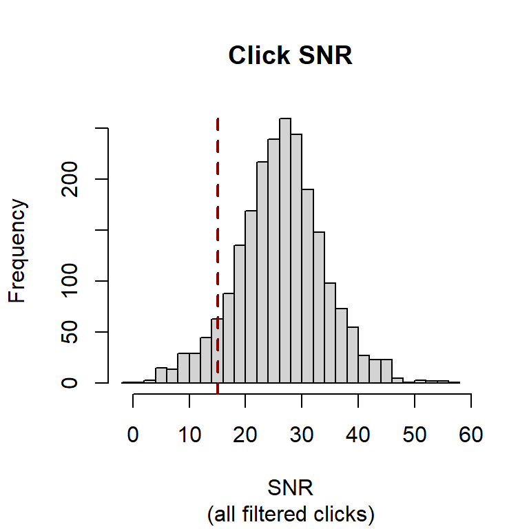

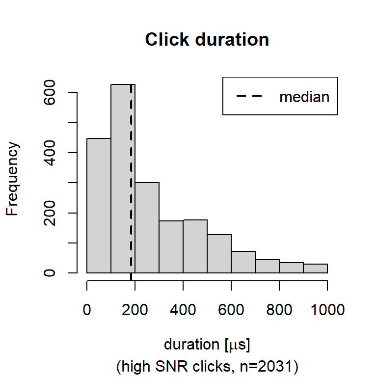

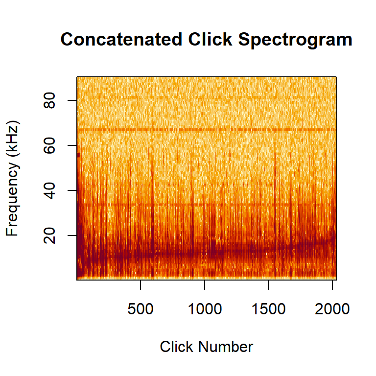

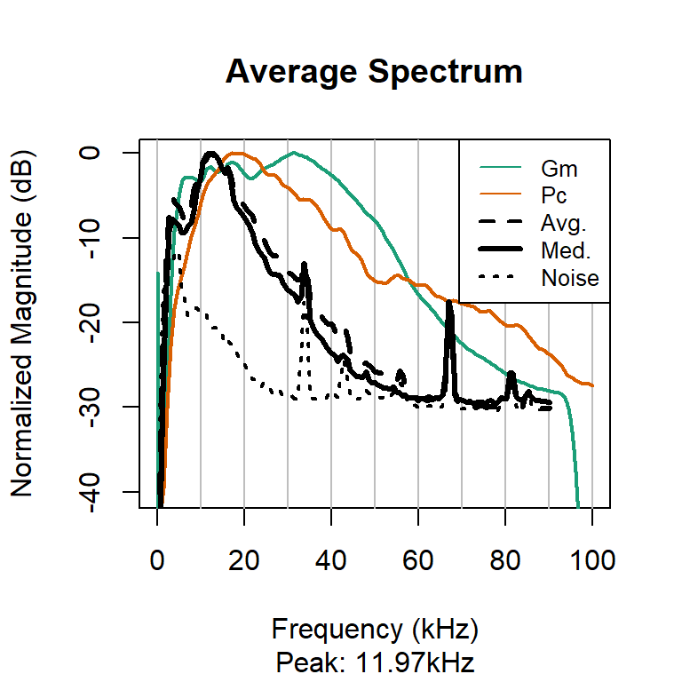

Median statistics for 2031 high SNR clicks with SNR >= 15 dB.

| parameter | value |
| --- | --- |
| Median Peak Frequency [kHz] | 12.4 |
| Median 3dB Center Frequency [kHz] | 12.4 |
| Median 10dB Center Frequency [kHz] | 12.4 |
| Median 3dB Bandwidth [kHz] (lower-upper) | 1.15 (11.6 - 13.1) |
| Median 10dB Bandwidth [kHz] (lower-upper) | 7.09 ( 8.6 - 16.3) |
| Median duration [μs] (25-75 percentile) | 183 (106 - 381) |

##### Whistle plots and table

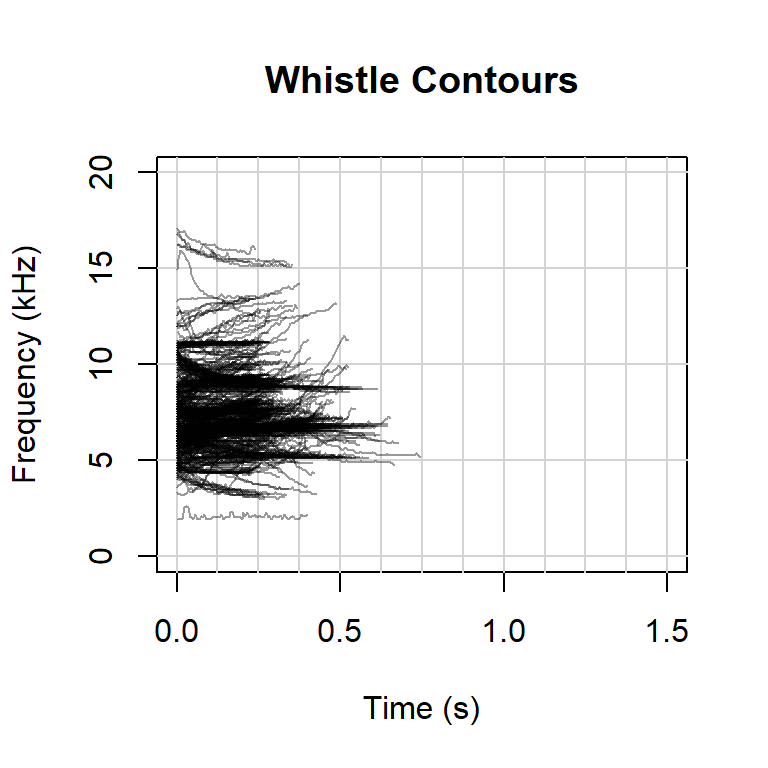

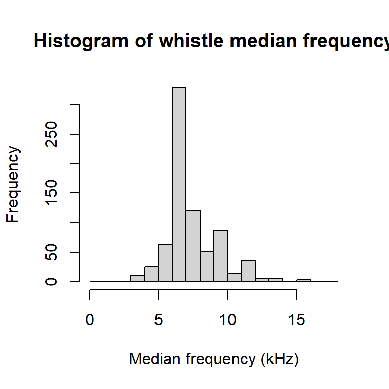

Median statistics for n = 755 whistles.

| parameter | value |
| --- | --- |
| Median begin frequency [kHz] | 6.60 |
| Median end frequency [kHz] | 7.31 |
| Median mean frequency [kHz] (SD) | 6.73 (0.24) |
| Median duration [s] | 0.29 |
| Median frequency range [kHz] (min-max) | 0.88 (6.25 - 7.39) |